# Analysis Musterlösung

Author

Sandra Grinschgl, Aaron Friedli, Lars Schilling

# 1 Analysis - Statistische Reproduktion von Grinschgl et al. (2021) mit simulierten Daten

Grinschgl, S., Meyerhoff, H.S., Schwan, S. *et al.* From metacognitive beliefs to strategy selection: does fake performance feedback influence cognitive offloading?. *Psychological Research* **85**, 2654–2666 (2021). https://doi.org/10.1007/s00426-020-01435-9

Dies ist eine von mehreren möglichen Lösungen für die Analysis- und Processing-Skripte. Da die Berichte individuell an Ihren spezifischen Datensatz angepasst wurden, bedeuten Abweichungen von dieser Vorlage **nicht,** dass Ihr Code oder Ihre Ergebnisse notwendigerweise falsch sind.

**Geben Sie diese Datei nicht weiter! Sie ist nur für Studierende zugänglich, die am Seminar “R u Ready” im Herbstsemester 2025 teilnehmen.**

# 2 Vorbereitungen

### 2.0.1 Notation

```r
options(scipen = 999)
```

### 2.0.2 Libraries

```r
library(readxl)
library(tidyverse)
library(kableExtra)
library(gtsummary)
library(afex)
library(effectsize)
library(car)
library(BayesFactor)
library(lmtest)
library(relaimpo)
library(onewaytests)
library(skimr)
library(inspectdf)
library(here)
```

### 2.0.3 Laden der bereingten Daten

```r
dat_full <- read_csv(here("data/processed/dat_full.csv"))
dat_full_long <- read_csv(here("data/processed/dat_full_long.csv"))
```

### 2.0.4 Faktoren setzen

```r
dat_full$group_all <- factor(dat_full$group_all, levels = c("below", "control", "above"))

levels(dat_full$group_all)
```

```
[1] "below"   "control" "above"
```

```r
dat_full_long$time_rating <- factor(dat_full_long$time_rating, levels = c("pre_1", "pre_4"))


levels(dat_full_long$time_rating) #Check Levels of Factor
```

```
[1] "pre_1" "pre_4"
```

# 3 Analysis

## 3.1 Analyse der Simulierten Daten

### 3.1.1 Deskriptiva (Means, SDs) (Werte müssen berechnet werden, Tabelle ist optional)

```r
dat_full_descrip <- dat_full |>
  dplyr::select(group_all, mean_rl_all, mean_e1_all, mean_d1_all, mean_d_all, cvstm_propcorrect) |>
  tbl_summary(
    by = group_all,
    statistic = all_continuous() ~ "{mean} ({sd})",
    digits = all_continuous() ~ 2,
    label = list(
      mean_rl_all = "Openings of the model window",
      mean_e1_all = "Initially correctly copied items",
      mean_d1_all = "Initial encoding duration (sec)",
      mean_d_all = "Trial duration (sec)",
      cvstm_propcorrect = "Working memory performance")
  ) |>
  modify_header(
    label = "",
    stat_1 = "Below-average group\n M (SD)",
    stat_2 = "Control-average group\n M (SD)",
    stat_3 = "Average group\n M (SD)") |>
  modify_footnote(everything() ~ NA)

dat_full_descrip
```

|  | Below-average group M (SD) | Control-average group M (SD) | Average group M (SD) |
| --- | --- | --- | --- |
| Openings of the model window | 4.91 (0.93) | 5.08 (0.74) | 5.10 (0.89) |
| Initially correctly copied items | 3.29 (0.51) | 3.27 (0.54) | 3.23 (0.51) |
| Initial encoding duration (sec) | 7.05 (2.71) | 6.62 (2.81) | 6.48 (2.10) |
| Trial duration (sec) | 40.42 (5.83) | 39.55 (6.53) | 40.24 (7.34) |
| Working memory performance | 0.72 (0.07) | 0.73 (0.07) | 0.74 (0.09) |

```r
# Save as CSV
#write.csv(dat_full_descrip, "./files/dat_full_descrip.csv", row.names = FALSE)
```

```r
#
```

### 3.1.2 Subjective Performance Ratings

*“To investigate whether the participants changed their metacognitive evaluations according to the provided fake performance feedback, we performed a preregistered **mixed 2 × 3 ANOVA** with the within factor “**time of pre-rating**” (first pre-rating before receiving any feedback vs. fourth pre-rating after receiving feedback for three times) and the between factor “feedback group” (below-average vs. above-average vs. control).”*

#### 3.1.2.1 2x3 ANOVA

```r
anovaMW <- aov_4(rating ~ group_all + (time_rating | code),
                 anova_table = list(es = c("ges", "pes")), #specify to obtain generalized and partial eta squared
                 data = dat_full_long)
```

```
Converting to factor: group_all
```

```
Contrasts set to contr.sum for the following variables: group_all
```

```r
anovaMW$anova_table
```

```
Anova Table (Type 3 tests)

Response: rating
                      num Df den Df    MSE      F     pes      ges
group_all                  2    156 219.88 20.846 0.21089 0.150829
time_rating                1    156 110.96 51.269 0.24736 0.099282
group_all:time_rating      2    156 110.96 66.797 0.46131 0.223129
                                     Pr(>F)
group_all                  0.00000000947730 ***
time_rating                0.00000000002978 ***
group_all:time_rating < 0.00000000000000022 ***
---
Signif. codes:  0 '***' 0.001 '**' 0.01 '*' 0.05 '.' 0.1 ' ' 1
```

```r
eta_squared(anovaMW, partial = FALSE) #eta squared as reported in the article
```

```
# Effect Size for ANOVA (Type III)

Parameter             | Eta2 |       95% CI
-------------------------------------------
group_all             | 0.11 | [0.04, 1.00]
time_rating           | 0.07 | [0.02, 1.00]
group_all:time_rating | 0.18 | [0.10, 1.00]

- One-sided CIs: upper bound fixed at [1.00].
```

Wir beobachteten einen signifikanten **main effect** des Faktors „**feedback group**“, $F$(2, 156) = 20.85, $p$ < .001, $\eta^2$ = 0.11, sowie einen signifikanten **main effect** des Faktors „**time of pre-rating**“, $F$(1, 156) = 51.27, $p$ < .001, $\eta^2$ = 0.07. Am wichtigsten ist jedoch, dass wir auch einen signifikanten **Interaktionseffekt** zwischen diesen Faktoren fanden, $F$(2, 156) = 66.8, $p$ < .001, $\eta^2$ = 0.18.

#### 3.1.2.2 Plot (optional)

```
Ignoring unknown labels:
• shape : "Feedback Group"
```

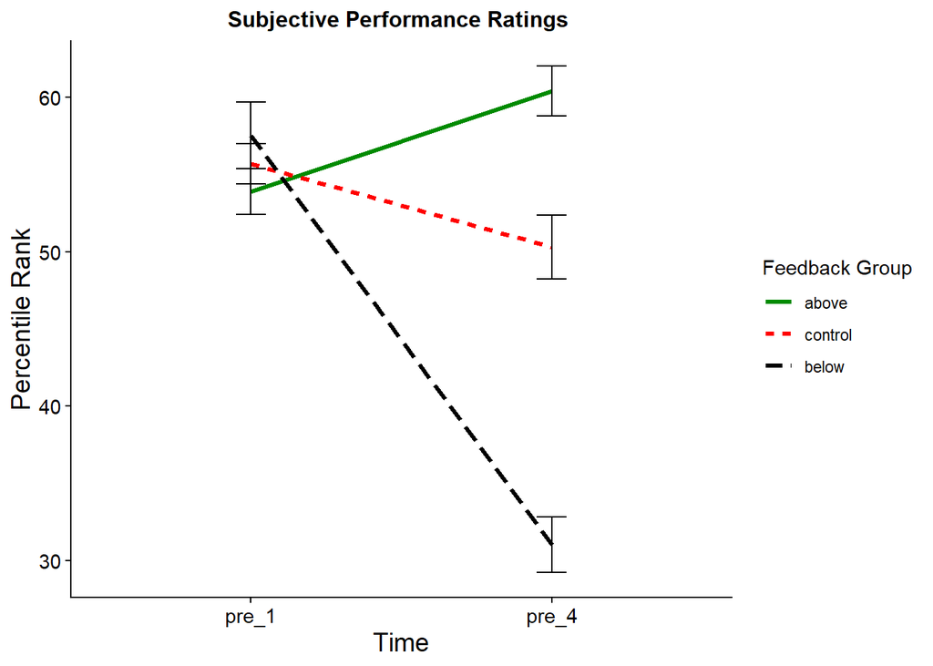

```r
descriptives <- dat_full_long |>
  group_by(group_all, time_rating) |>
  summarize(N = length(rating),
               mean_d = mean(rating),
               sd_d   = sd(rating),
               se_d   = sd_d / sqrt(N)
)
descriptives$group_all <- factor(descriptives$group_all, c("above", "control", "below"))

rate_plot <- descriptives |>
  ggplot(aes(x = time_rating,
             y = mean_d,
             group = group_all))

rate_plot +
  geom_line(aes(color = group_all, linetype = group_all), size = 1.2) +
  geom_errorbar(aes(ymin = mean_d - se_d, ymax = mean_d + se_d), width = .1) +
  scale_color_manual(values = c("green4", "red", "black")) +
  theme_classic() +
  labs(title = "Subjective Performance Ratings ") +
  ylab("Percentile Rank") +
  xlab("Time") +
  theme(plot.title = element_text(hjust = 0.5, size = 12, face = "bold"),
        axis.text = element_text(size = 11), axis.title = element_text(size = 14)) +
  labs(colour = "Feedback Group", linetype = "Feedback Group", shape = "Feedback Group")
```

#### 3.1.2.3 Post-hoc t-Tests

```r
# Subset
aboveRating <- subset(dat_full_long, group_all == "above")
controlRating <- subset(dat_full_long, group_all == "control")
belowRating <- subset(dat_full_long, group_all == "below")

# Above-average vs. Control at Pre 1
t.test(aboveRating$rating[aboveRating$time_rating == "pre_1"], controlRating$rating[controlRating$time_rating == "pre_1"], var.equal = TRUE)
```

```
    Two Sample t-test

data:  aboveRating$rating[aboveRating$time_rating == "pre_1"] and controlRating$rating[controlRating$time_rating == "pre_1"]
t = -0.89978, df = 104, p-value = 0.3703
alternative hypothesis: true difference in means is not equal to 0
95 percent confidence interval:
 -5.682417  2.135247
sample estimates:
mean of x mean of y
 53.90566  55.67925
```

```r
effsize::cohen.d(aboveRating$rating[aboveRating$time_rating == "pre_1"], controlRating$rating[controlRating$time_rating == "pre_1"])
```

```
Cohen's d

d estimate: -0.1747885 (negligible)
95 percent confidence interval:
     lower      upper
-0.5607426  0.2111656
```

```r
# Above-average vs. Below-average at Pre 1
t.test(aboveRating$rating[aboveRating$time_rating == "pre_1"], belowRating$rating[belowRating$time_rating == "pre_1"], var.equal = TRUE)
```

```
    Two Sample t-test

data:  aboveRating$rating[aboveRating$time_rating == "pre_1"] and belowRating$rating[belowRating$time_rating == "pre_1"]
t = -1.3807, df = 104, p-value = 0.1703
alternative hypothesis: true difference in means is not equal to 0
95 percent confidence interval:
 -8.825808  1.580525
sample estimates:
mean of x mean of y
 53.90566  57.52830
```

```r
# Below-average vs. Control at Pre 1
t.test(belowRating$rating[belowRating$time_rating == "pre_1"], controlRating$rating[controlRating$time_rating == "pre_1"], var.equal = TRUE)
```

```
    Two Sample t-test

data:  belowRating$rating[belowRating$time_rating == "pre_1"] and controlRating$rating[controlRating$time_rating == "pre_1"]
t = 0.7316, df = 104, p-value = 0.4661
alternative hypothesis: true difference in means is not equal to 0
95 percent confidence interval:
 -3.162889  6.861002
sample estimates:
mean of x mean of y
 57.52830  55.67925
```

```r
# Above-average vs. Control at Pre 4
t.test(aboveRating$rating[aboveRating$time_rating == "pre_4"], controlRating$rating[controlRating$time_rating == "pre_4"], var.equal = TRUE)
```

```
    Two Sample t-test

data:  aboveRating$rating[aboveRating$time_rating == "pre_4"] and controlRating$rating[controlRating$time_rating == "pre_4"]
t = 3.8505, df = 104, p-value = 0.0002039
alternative hypothesis: true difference in means is not equal to 0
95 percent confidence interval:
  4.904792 15.321623
sample estimates:
mean of x mean of y
 60.41509  50.30189
```

```r
effsize::cohen.d(aboveRating$rating[aboveRating$time_rating == "pre_4"], controlRating$rating[controlRating$time_rating == "pre_4"])
```

```
Cohen's d

d estimate: 0.7479822 (medium)
95 percent confidence interval:
    lower     upper
0.3495204 1.1464439
```

```r
# Above-average vs. Below-average at Pre 4
t.test(aboveRating$rating[aboveRating$time_rating == "pre_4"], belowRating$rating[belowRating$time_rating == "pre_4"], var.equal = TRUE)
```

```
    Two Sample t-test

data:  aboveRating$rating[aboveRating$time_rating == "pre_4"] and belowRating$rating[belowRating$time_rating == "pre_4"]
t = 12.184, df = 104, p-value < 0.00000000000000022
alternative hypothesis: true difference in means is not equal to 0
95 percent confidence interval:
 24.61192 34.18053
sample estimates:
mean of x mean of y
 60.41509  31.01887
```

```r
# Below-average vs. Control at Pre 4
t.test(belowRating$rating[belowRating$time_rating == "pre_4"], controlRating$rating[controlRating$time_rating == "pre_4"], var.equal = TRUE)
```

```
    Two Sample t-test

data:  belowRating$rating[belowRating$time_rating == "pre_4"] and controlRating$rating[controlRating$time_rating == "pre_4"]
t = -7.0056, df = 104, p-value = 0.0000000002519
alternative hypothesis: true difference in means is not equal to 0
95 percent confidence interval:
 -24.74133 -13.82471
sample estimates:
mean of x mean of y
 31.01887  50.30189
```

Beim vierten **pre-rating** hingegen unterschieden sich alle Gruppen voneinander, alle $|t|$(104) $\ge$ 3.85, alle $p \le$ < .001, alle $|d| \ge$ 0.75.

### 3.1.3 Cognitive Offloading

#### 3.1.3.1 ANOVAs

```r
anovaRL <- aov_4(mean_rl_all ~ (group_all)+ (1 | code), data = dat_full)
```

```
Contrasts set to contr.sum for the following variables: group_all
```

```r
summary(anovaRL)
```

```
Anova Table (Type 3 tests)

Response: mean_rl_all
          num Df den Df     MSE      F     ges Pr(>F)
group_all      2    156 0.73207 0.8245 0.01046 0.4403
```

```r
eta_squared(anovaRL, partial = FALSE)
```

```
# Effect Size for ANOVA (Type III)

Parameter | Eta2 |       95% CI
-------------------------------
group_all | 0.01 | [0.00, 1.00]

- One-sided CIs: upper bound fixed at [1.00].
```

```r
anovaE1 <- aov_4(mean_e1_all ~ (group_all)+ (1 | code), data = dat_full)
```

```
Contrasts set to contr.sum for the following variables: group_all
```

```r
summary(anovaE1)
```

```
Anova Table (Type 3 tests)

Response: mean_e1_all
          num Df den Df    MSE      F       ges Pr(>F)
group_all      2    156 0.2694 0.2005 0.0025638 0.8185
```

```r
eta_squared(anovaE1, partial = FALSE)
```

```
# Effect Size for ANOVA (Type III)

Parameter |     Eta2 |       95% CI
-----------------------------------
group_all | 2.56e-03 | [0.00, 1.00]

- One-sided CIs: upper bound fixed at [1.00].
```

```r
anovaD1 <- aov_4(mean_d1_all ~ (group_all)+ (1 | code), data = dat_full)
```

```
Contrasts set to contr.sum for the following variables: group_all
```

```r
summary(anovaD1)
```

```
Anova Table (Type 3 tests)

Response: mean_d1_all
          num Df den Df    MSE      F       ges Pr(>F)
group_all      2    156 6.5445 0.7149 0.0090823 0.4908
```

```r
eta_squared(anovaD1, partial = FALSE)
```

```
# Effect Size for ANOVA (Type III)

Parameter |     Eta2 |       95% CI
-----------------------------------
group_all | 9.08e-03 | [0.00, 1.00]

- One-sided CIs: upper bound fixed at [1.00].
```

Die drei **feedback groups** unterschieden sich nicht signifikant in der Häufigkeit, mit der das **model window** geöffnet wurde, $F$(2, 156) = 0.82, $p$ = 0.440, $\eta^2$ = 0.01, der Anzahl der initial korrekt kopierten Items (**initially correctly copied items**), $F$(2, 156) = 0.2, $p$ = 0.819, $\eta^2$ < 0.01, und der initialen Kodierungsdauer (**initial encoding duration**), $F$(2, 156) = 0.71, $p$ = 0.491, $\eta^2$ < 0.01.

### 3.1.4 Trial Duration

#### 3.1.4.1 ANOVA

```r
anovaDur <- aov_4(mean_d_all ~ as.factor(group_all)+ (1 | code), data = dat_full)
```

```
Contrasts set to contr.sum for the following variables: group_all
```

```r
summary(anovaDur)
```

```
Anova Table (Type 3 tests)

Response: mean_d_all
                     num Df den Df    MSE      F       ges Pr(>F)
as.factor(group_all)      2    156 43.446 0.2564 0.0032769 0.7741
```

```r
eta_squared(anovaDur, partial = FALSE)
```

```
# Effect Size for ANOVA (Type III)

Parameter            |     Eta2 |       95% CI
----------------------------------------------
as.factor(group_all) | 3.28e-03 | [0.00, 1.00]

- One-sided CIs: upper bound fixed at [1.00].
```

Für explorative Zwecke analysierten wir auch die **trial duration** innerhalb des **Pattern Copy Task** als Indikator für die **task performance**.

Die drei **feedback groups** unterschieden sich nicht signifikant in der **trial duration**, $F$(2, 156) = 0.26, $p$ = 0.774, $\eta^2$ < 0.01.

### 3.1.5 MMQ (Multifactorial Memory Questionnaire)

#### 3.1.5.1 ANOVA

```r
anovaMMQ = aov_4(mmq_mean ~ group_all + (1 | code), data = dat_full)
```

```
Contrasts set to contr.sum for the following variables: group_all
```

```r
summary(anovaMMQ)
```

```
Anova Table (Type 3 tests)

Response: mmq_mean
          num Df den Df     MSE      F     ges     Pr(>F)
group_all      2    156 0.34082 10.653 0.12017 0.00004605 ***
---
Signif. codes:  0 '***' 0.001 '**' 0.01 '*' 0.05 '.' 0.1 ' ' 1
```

```r
eta_squared(anovaMMQ, partial = FALSE)
```

```
# Effect Size for ANOVA (Type III)

Parameter | Eta2 |       95% CI
-------------------------------
group_all | 0.12 | [0.05, 1.00]

- One-sided CIs: upper bound fixed at [1.00].
```

Eine explorative **one-way ANOVA** ergab signifikante Gruppenunterschiede hinsichtlich der Überzeugungen über die eigenen allgemeinen Gedächtnisfähigkeiten (**beliefs about one’s general memory abilities**) am Ende des Experiments, $F$(2, 156) = 10.65, $p$ < .001, $\eta^2$ = 0.12.

#### 3.1.5.2 Post-hoc t-Tests

```r
above <- subset(dat_full, group_all == "above")
below <- subset(dat_full, group_all == "below")
control <- subset(dat_full, group_all == "control")

# t-tests comparing mmq_mean across the groups
# datasets must contain variable "mmq_mean"

t.test(above$mmq_mean, below$mmq_mean, var.equal = TRUE)
```

```
    Two Sample t-test

data:  above$mmq_mean and below$mmq_mean
t = 4.5271, df = 104, p-value = 0.00001597
alternative hypothesis: true difference in means is not equal to 0
95 percent confidence interval:
 0.2798028 0.7160044
sample estimates:
mean of x mean of y
 2.076520  1.578616
```

```r
t.test(control$mmq_mean, below$mmq_mean, var.equal = TRUE)
```

```
    Two Sample t-test

data:  control$mmq_mean and below$mmq_mean
t = 3.3665, df = 104, p-value = 0.001068
alternative hypothesis: true difference in means is not equal to 0
95 percent confidence interval:
 0.1598131 0.6179647
sample estimates:
mean of x mean of y
 1.967505  1.578616
```

```r
t.test(control$mmq_mean, above$mmq_mean, var.equal = TRUE)
```

```
    Two Sample t-test

data:  control$mmq_mean and above$mmq_mean
t = -0.95093, df = 104, p-value = 0.3438
alternative hypothesis: true difference in means is not equal to 0
95 percent confidence interval:
 -0.3363497  0.1183203
sample estimates:
mean of x mean of y
 1.967505  2.076520
```

```r
#Calculate Cohen's d for the comparisons

effsize::cohen.d(above$mmq_mean, below$mmq_mean)
```

```
Cohen's d

d estimate: 0.8794193 (large)
95 percent confidence interval:
    lower     upper
0.4760095 1.2828291
```

```r
effsize::cohen.d(control$mmq_mean, below$mmq_mean)
```

```
Cohen's d

d estimate: 0.6539647 (medium)
95 percent confidence interval:
    lower     upper
0.2585828 1.0493465
```

```r
effsize::cohen.d(control$mmq_mean, above$mmq_mean)
```

```
Cohen's d

d estimate: -0.1847254 (negligible)
95 percent confidence interval:
     lower      upper
-0.5707654  0.2013145
```

Zusätzliche **t-tests** für **independent samples** zeigten, dass die **below-average group** ihre allgemeinen Gedächtnisfähigkeiten niedriger als die **above-average group** bewertete, $t$(104) = 4.53, $p$ < .001, $d$ = 0.88, und ebenfalls niedriger als die **control group**, $t$(104) = 3.37, $p$ = 0.001, $d$ = 0.65.

Wir beobachteten keinen signifikanten Unterschied zwischen der **above-average group** und der **control group**, $t$(104) = 0.95, $p$ = 0.344, $d$ = 0.18 .

### 3.1.6 Working Memory Capacity

```r
anova_cvstm <- aov_4(cvstm_propcorrect ~ (group_all)+ (1 | code), data = dat_full)
```

```
Contrasts set to contr.sum for the following variables: group_all
```

```r
summary(anova_cvstm)
```

```
Anova Table (Type 3 tests)

Response: cvstm_propcorrect
          num Df den Df       MSE      F       ges Pr(>F)
group_all      2    156 0.0058257 0.4216 0.0053755 0.6568
```

```r
eta_squared(anova_cvstm, partial = FALSE)
```

```
# Effect Size for ANOVA (Type III)

Parameter |     Eta2 |       95% CI
-----------------------------------
group_all | 5.38e-03 | [0.00, 1.00]

- One-sided CIs: upper bound fixed at [1.00].
```

Eine **one-way ANOVA** ergab, dass es keine signifikanten Gruppenunterschiede bei diesem Maß der **working memory performance** gab, $F$(2, 156) = 0.42, $p$ = 0.657, $\eta^2$ < 0.01.

### 3.1.7 Tabelle oder Plot of freier Wahl

```r
group_summary <- dat_full |>
  group_by(group_all) |>
  summarize(
    mean_mmq = mean(mmq_mean),
    se_mmq = sd(mmq_mean, na.rm = TRUE) / sqrt(sum(!is.na(mmq_mean)))
  )
```

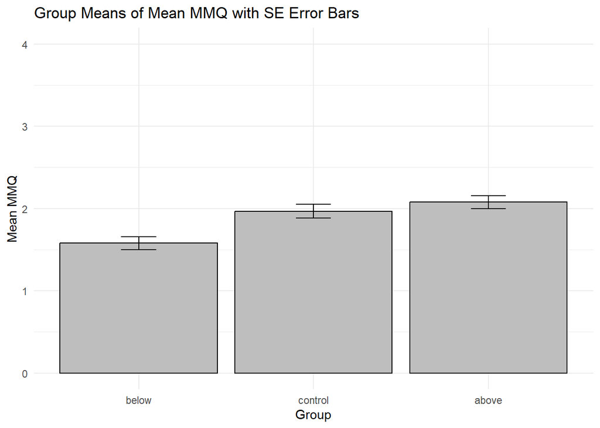

```r
ggplot(group_summary, aes(x = group_all, y = mean_mmq)) +
  geom_col(fill = "gray", color = "black") +
  geom_errorbar(
    aes(ymin = mean_mmq - se_mmq, ymax = mean_mmq + se_mmq),
    width = 0.2,
    color = "black"
  ) +
  labs(
    x = "Group",
    y = "Mean MMQ",
    title = "Group Means of Mean MMQ with SE Error Bars"
  ) +
  theme_minimal() +
  ylim(0, 4)
```

# 4 Information

This script was created and ran in

```
R version 4.5.1
```

## References

Grinschgl, Sandra, Hauke S. Meyerhoff, Stephan Schwan, and Frank Papenmeier. 2021. “From Metacognitive Beliefs to Strategy Selection: Does Fake Performance Feedback Influence Cognitive Offloading?” *Psychological Research* 85 (7): 2654–66. https://doi.org/10.1007/s00426-020-01435-9.